# Reproducible, collaborative workflow with Github and R Markdown

Julie Lowndes

July 13, 2016

# 1 Objectives

1. make a new repo with gh-pages branch, clone it
2. learn markdown, practice
3. learn Rmarkdown, practice data wrangling with gapminder data (index.rmd)
4. introduce ggplot briefly, and interactive graphics
5. push to github.com; new website!
6. add their neighbor as a collaborator to their repo
7. practice more; make changes to their repo, and to their neighbor’s.

*Note:* Today’s materials were developed for and borrowing from:

- Ben Best’s Software Carpentry at UCSB [git lesson](http://remi-daigle.github.io/2016-04-15-UCSB/git/) and [Visualization in R lesson](http://remi-daigle.github.io/2016-04-15-UCSB/viz/).

# 2 Create repository with gh-pages branch

1. [Create a repository](https://help.github.com/articles/create-a-repo/) called `my-project`. This is just like we did this morning. It’s good to create new repos for new projects.

[figure not shown]

   Please be sure to tick the box to **Initialize this repository with a README**. Otherwise defaults are fine.

[figure not shown]

2. [Create a branch](https://help.github.com/articles/creating-and-deleting-branches-within-your-repository/) called `gh-pages`.

[figure not shown]

   This morning we were able to view our rendered .html pages online with rawgit. But a `gh-pages` branch lets you have a clean url, which will be `http://USER.github.io/REPO` (see more info at pages.github.com and [User, Organization, and Project Pages - Github Help](https://help.github.com/articles/user-organization-and-project-pages/)).
3. [Set the default branch](https://help.github.com/articles/setting-the-default-branch/) to `gh-pages`, NOT the default `master`.

[figure not shown]

4. [Delete the branch](https://help.github.com/articles/viewing-branches-in-your-repository/#deleting-branches) `master`, which will not be used.

# 3 Clone the repo to your computer

Do this with RStudio if it’s working for you, or with the GitHub Desktop App.

# 4 Intro to Markdown

Let’s learn markdown by editing the `README.md` on github.com for convenience. A README.md file can be added to every folder in a repository, and they are automatically displayed when the repository is opened on github.com

The `README.md` is in **markdown**, simple syntax for conversion to HTML. `.md` is a kind of text file, so you only need a text editor to read it. If you were editing this on your computer, you could do this right in RStudio, which has a built-in text editor. (You could also do it in another text editor program, but RStudio is convenient). Copy-paste the following into your `README.md`:

```
# my-project

Playing with [Software Carpentry at Oxford](http://jule32.github.io/2016-07-12-Oxford).

## Introduction

This repository demonstrates **software** and _formats_:

1. **Git**
1. **Github**
1. _Markdown_
1. _Rmarkdown_

## Conclusion

![](https://octodex.github.com/images/labtocat.png)
```

Now click on the Preview button to see the markdown rendered as HTML.

Notice the syntax for:

- **numbered list** gets automatically sequenced: `1.`, `1.`
- **headers** get rendered at multiple levels: `#`, `##`
- **link**: `[](http://...)`
- **image**: `![](http://...)`
- *italics*: `_word_`
- **bold**: `**word**`

There are some good [cheatsheets](https://github.com/adam-p/markdown-here/wiki/Markdown-Here-Cheatsheet) to get you started, and here is one built into RStudio:

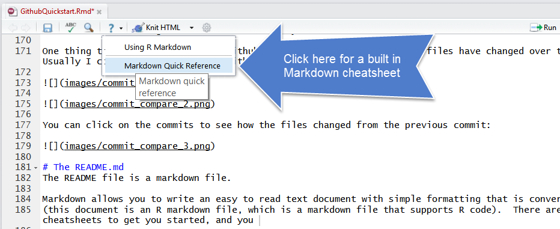

See [Mastering Markdown · GitHub Guides](https://guides.github.com/features/mastering-markdown/) and add some more personalized content to the README of your own, like a bulleted list or blockquote. For on the fly rendering, the [atom](https://atom.io/) text editor is good.

# 5 Commit this README.md

Have a look through the repo on github.com to see the updates you’ve made, and notice that it renders below the files in the repo. This is a unique trait of README.md

# 6 Rmarkdown from RStudio

Back in RStudio, let’s create a new Rmarkdown file, which allows us to weave markdown text with chunks of R code to be evaluated and output content like tables and plots.

File -> New File -> Rmarkdown… -> Document of output format HTML, OK.

[figure not shown]

You can give it a Title of “My Project”. After you click OK, most importantly File -> Save as `index` (which will get named with the filename extension `index.Rmd`).

Some initial text is already provided for you. Let’s go ahead and “Knit HTML”.

Notice how the markdown is rendered similar to as before + **R code chunks** are surrounded by 3 backticks and `{r LABEL}`. These are evaluated and return the output text in the case of `summary(cars)` and the output plot in the case of `plot(pressure)`.

Notice how the code `plot(pressure)` is not shown in the HTML output because of the R code chunk option `echo=FALSE`.

**Before we continue exploring Rmarkdown**, let’s sync this the .rmd and .html to github.com. Enter a message like “added index” and click on “Commit and Sync gh-pages”. This will update https://github.com/USER/my-project, and now you can also see your project website with a default `index.html` viewable at http://USER.github.io/my-project

## 6.1 Resources

Were you hoping for an RStudio Cheatsheet? Here it is:

- [rmarkdown-cheatsheet.pdf](http://www.rstudio.com/wp-content/uploads/2016/03/rmarkdown-cheatsheet-2.0.pdf)
- http://rmarkdown.rstudio.com
- [knitr in a knutshell - Karl Broman](http://kbroman.org/knitr_knutshell/)

# 7 Visualization in R - brief intro

Let’s start a new .Rmd file and we’ll do this within an R chunk.

Great resources:

- [RStudio data visualization cheatsheet](http://www.rstudio.com/wp-content/uploads/2015/12/ggplot2-cheatsheet-2.0.pdf) (screenshots below)
- [Creating publication quality graphics - Software Carpentry](http://swcarpentry.github.io/r-novice-gapminder/08-plot-ggplot2.html)

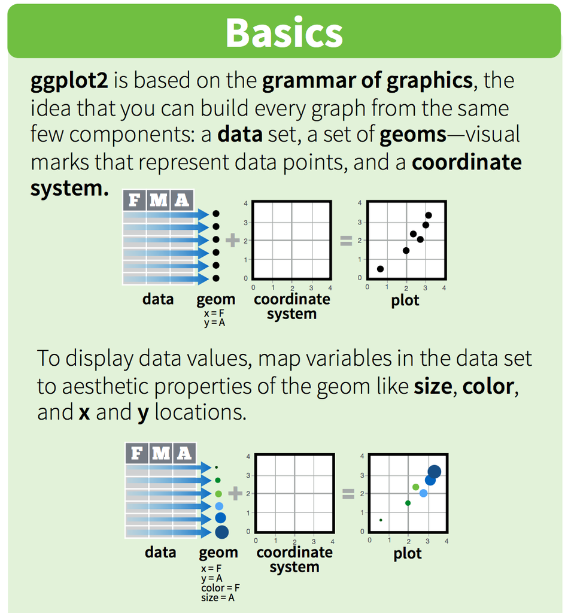

## 7.1 Static plots with `ggplot2`

```r
## load libraries
library(dplyr) # you need to have all libraries loaded within the Rmd file
library(ggplot2) #install.packages('ggplot2')
library(gapminder)

# get range of available data
summary(gapminder)
```

### 7.1.1 Scatterplot

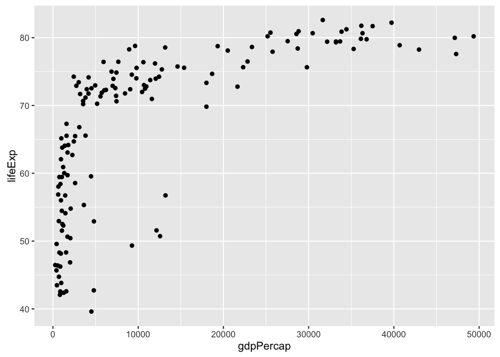

```r
# setup dataframe
g = gapminder %>%
  filter(year==2007) %>%   # most recent year
  mutate(pop_m = pop/1e6)  # population, millions

# plot scatterplot of most recent year
s = ggplot(g, aes(x=gdpPercap, y=lifeExp)) +
  geom_point()
s
```

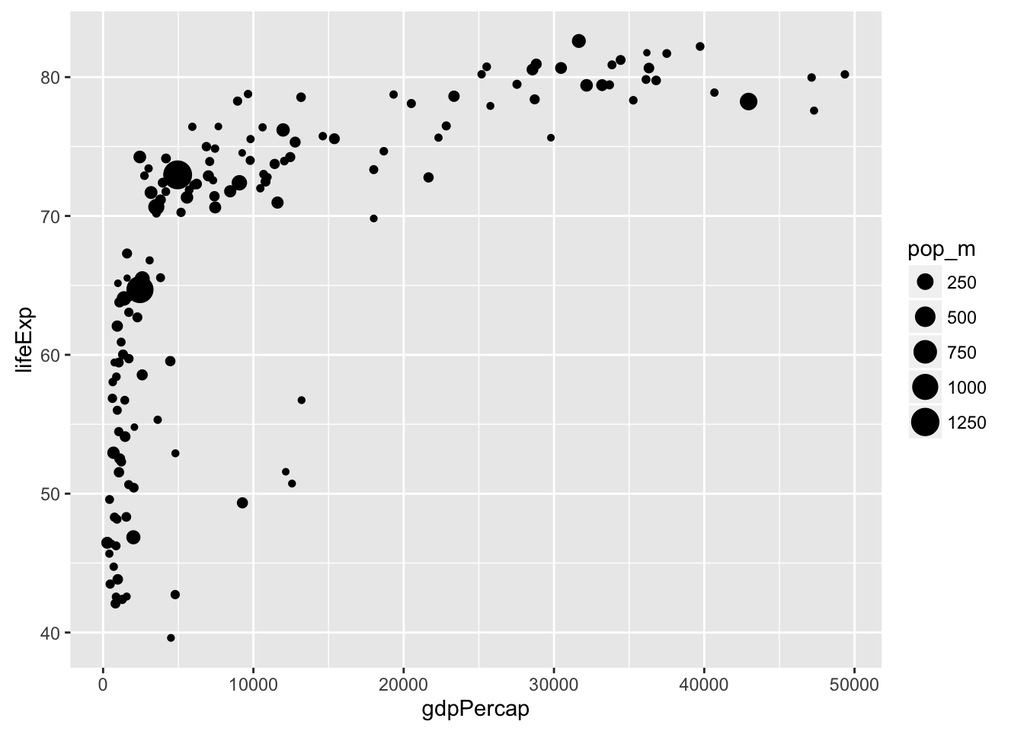

```r
# add aesthetic of size by population
s = s +
  aes(size=pop_m)
s
```

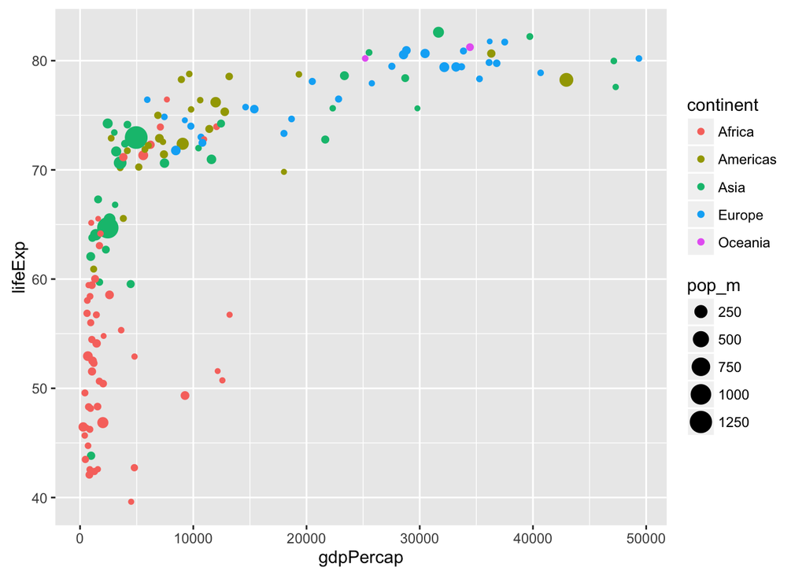

```r
# add aesthetic of color by continent
s = s +
  aes(color=continent)
s
```

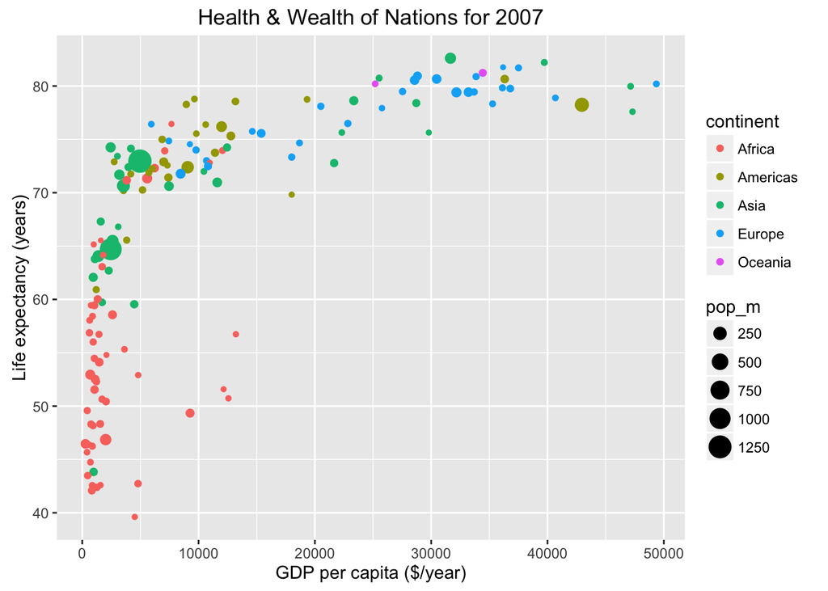

```r
# add title, update axes labels
s = s +
  ggtitle('Health & Wealth of Nations for 2007') +
  xlab('GDP per capita ($/year)') +
  ylab('Life expectancy (years)')
s
```

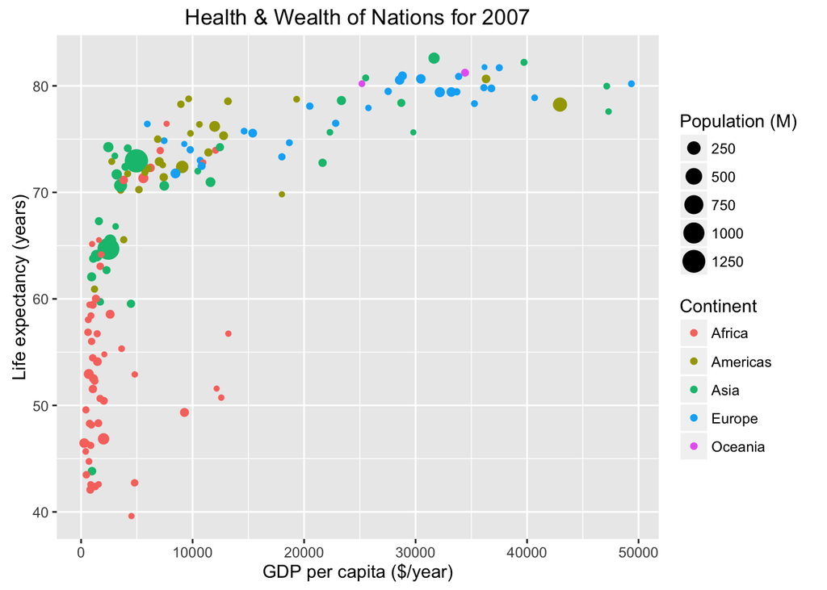

```r
# label legend
s = s +
  scale_colour_discrete(name='Continent') +
  scale_size_continuous(name='Population (M)')
s
```

### 7.1.2 Boxplot

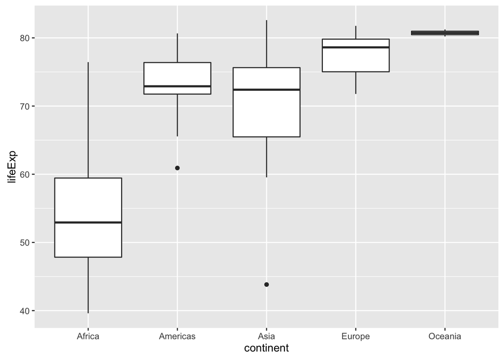

```r
# boxplot by continent
b = ggplot(g, aes(x=continent, y=lifeExp)) +
  geom_boxplot()
b
```

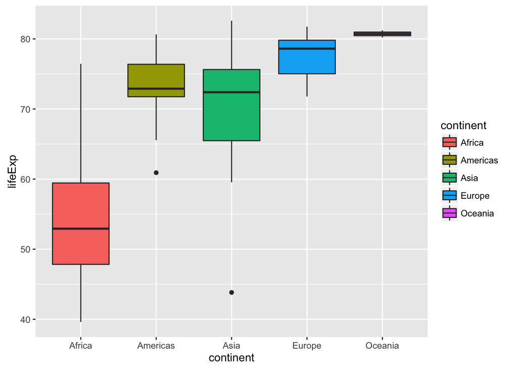

```r
# match color to continents, like scatterplot
b = b +
  aes(fill=continent)
b
```

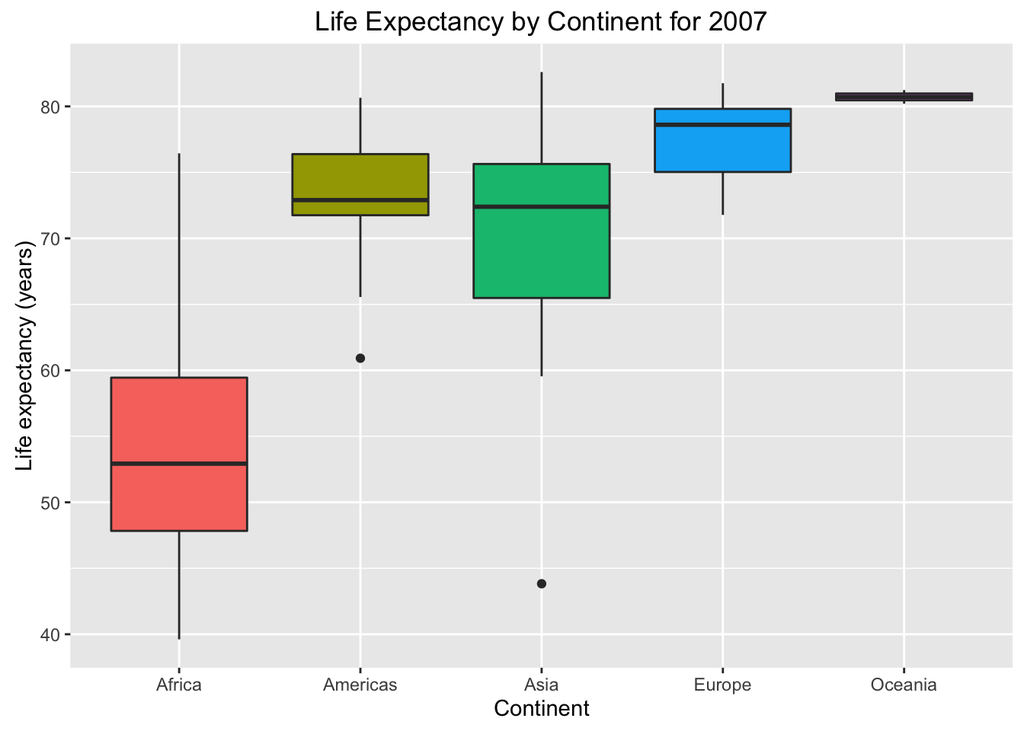

```r
# drop legend, add title, update axes labels
b = b +
  theme(legend.position='none') +
  ggtitle('Life Expectancy by Continent for 2007') +
  xlab('Continent') +
  ylab('Life expectancy (years)')
b
```

## 7.2 Interactive: `plotly`

[ggplot2 | plotly](https://plot.ly/ggplot2/)

```r
library(plotly) # install.packages('plotly')

# scatterplot (Note: key=country shows up on rollover)
s = ggplot(g, aes(x=gdpPercap, y=lifeExp, key=country)) +
  geom_point()
ggplotly(s) # must comment out or have eval=FALSE to knit

# boxplot
ggplotly(b) # must comment out or have eval=FALSE to knit
```

**Your Turn**: Expand the interactive scatterplot to include all the other bells and whistles of the previous plot in one continuous set of code (no in between setting of s).

## 7.3 Interactive: Motion Plot

The `googleVis` package ports most of the [Google charts](https://developers.google.com/chart/interactive/docs/gallery) functionality.

For every R chunk must set option `results='asis'`, and once before any googleVis plots, set `op <- options(gvis.plot.tag='chart')`.

- [Rmarkdown and googleVis](https://cran.r-project.org/web/packages/googleVis/vignettes/Using_googleVis_with_knitr.html)
- [googleVis examples](https://cran.r-project.org/web/packages/googleVis/vignettes/googleVis_examples.html)

```r
suppressPackageStartupMessages({
  library(googleVis) # install.packages('googleVis')
})
```

```r
op <- options(gvis.plot.tag='chart')

m = gvisMotionChart(
  gapminder %>%
    mutate(
      pop_m = pop / 1e6,
      log_gdpPercap = log(gdpPercap)),
  idvar='country',
  timevar='year',
  xvar='log_gdpPercap',
  yvar='lifeExp',
  colorvar='continent',
  sizevar='pop_m')
plot(m)
```

**Your Turn**: Repeat the motion chart with the country having the highest `gdpPercap` filtered out.

# 8 Push to github.com, explore your webpage

# 9 Add your neighbor as a collaborator

In github.com; we’ll walk through this together. Then, practice more; make changes to their repo, and to their neighbor’s.

# 10 Wrapup

# 11 If there’s time

## 11.1 Maps

Thematic maps [**`tmap`**](https://github.com/mtennekes/tmap):

- [tmap in a nutshell](https://cran.r-project.org/web/packages/tmap/vignettes/tmap-nutshell.html)
- [tmap modes: plot and interactive view](https://cran.r-project.org/web/packages/tmap/vignettes/tmap-modes.html)

### 11.1.1 Static

```r
library(tmap) # install.packages('tmap')

# load world spatial polygons
data(World)

# inspect values in World
World@data %>% tbl_df()

# gapminder countries not in World. skipping for now
g %>%
  anti_join(World@data, by=c('country'='name')) %>%
  arrange(desc(pop))

# World countries not in gapminder. skipping for now
World@data %>%
  anti_join(g, by=c('name'='country')) %>%
  arrange(desc(pop_est)) %>%
  select(iso_a3, name, pop_est)

# join gapminder data to World
World@data = World@data %>%
  left_join(g, by=c('name'='country'))
```

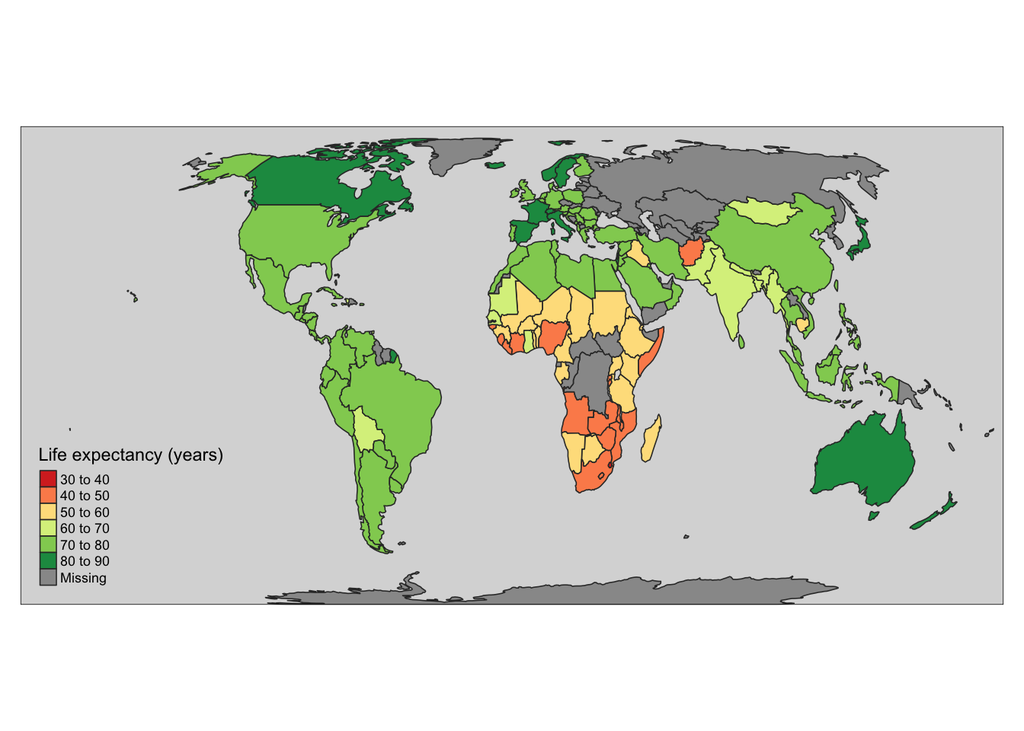

```r
# make map
m = tm_shape(World) +
    tm_polygons('lifeExp', palette='RdYlGn', id='name', title='Life expectancy (years)', auto.palette.mapping=F) +
    tm_style_gray() + tm_format_World()
m
```

## 11.2 Interactive

```r
# show interactive map
tmap_leaflet(m)
```

[interactive chart not shown]

# 12 References

- ggplot2-cheatsheet-2.0.pdf
- [Interactive Plots and Maps - Environmental Informatics](http://ucsb-bren.github.io/env-info/wk06_widgets.html)
- [Graphs with ggplot2 - Cookbook for R](http://www.cookbook-r.com/Graphs/#graphs-with-ggplot2)
- [ggplot2 Essentials - STHDA](http://www.sthda.com/english/wiki/ggplot2-essentials)
- [NEON Working with Geospatial Data](http://neon-workwithdata.github.io/NEON-R-Spatio-Temporal-Data-and-Management-Intro/)